# Reproducible Research: Project 1

Camille Tolentino

10/3/2020

# Introduction

It is now possible to collect a large amount of data about personal movement using activity monitoring devices such as a Fitbit, Nike Fuelband, or Jawbone Up. These type of devices are part of the “quantified self” movement – a group of enthusiasts who take measurements about themselves regularly to improve their health, to find patterns in their behavior, or because they are tech geeks. But these data remain under-utilized both because the raw data are hard to obtain and there is a lack of statistical methods and software for processing and interpreting the data.

This assignment makes use of data from a personal activity monitoring device. This device collects data at 5 minute intervals through out the day. The data consists of two months of data from an anonymous individual collected during the months of October and November, 2012 and include the number of steps taken in 5 minute intervals each day.

The data for this assignment can be downloaded from the course web site: [Activity monitoring data](https://d396qusza40orc.cloudfront.net/repdata%2Fdata%2Factivity.zip)

The variables included in this dataset are:

**steps**: Number of steps taking in a 5-minute interval (missing values are coded as `NA`)  
**date**: The date on which the measurement was taken in YYYY-MM-DD format  
**interval**: Identifier for the 5-minute interval in which measurement was taken The dataset is stored in a comma-separated-value (CSV) file and there are a total of 17,568 observations in this dataset.

# Goal of the code and this markdown file

1. Code for reading in the dataset and/or processing the data
2. Histogram of the total number of steps taken each day
3. Mean and median number of steps taken each day
4. Time series plot of the average number of steps taken
5. The 5-minute interval that, on average, contains the maximum number of steps
6. Code to describe and show a strategy for imputing missing data
7. Histogram of the total number of steps taken each day after missing values are imputed
8. Panel plot comparing the average number of steps taken per 5-minute interval across weekdays and weekends
9. All of the R code needed to reproduce the results (numbers, plots, etc.) in the report

### Obtaining data

Data is taken from course website and is available from [data source](https://d396qusza40orc.cloudfront.net/repdata%2Fdata%2Factivity.zip)

Check if file is already existing and if not, download the file. If the file is present, check if it has already been unzipped and if not, unzip file. We also need to make sure we know when the data was downloaded in case it changes over time.

```r
url <- "https://d396qusza40orc.cloudfront.net/repdata%2Fdata%2Factivity.zip"
path <- getwd()
dataFile <- "dataFiles.zip"

if (!file.exists(dataFile)){
  download.file(url, file.path(path, dataFile))
}
if (!file.exists("activity.csv")){
  unzip(dataFile)
}
tstp <- date()
tstp
```

```
## [1] "Sat Oct 03 14:26:21 2020"
```

Read the data and display summary

```r
activity <- data.table::fread(input = "activity.csv")
summary(activity)
```

```
##      steps             date               interval
##  Min.   :  0.00   Min.   :2012-10-01   Min.   :   0.0
##  1st Qu.:  0.00   1st Qu.:2012-10-16   1st Qu.: 588.8
##  Median :  0.00   Median :2012-10-31   Median :1177.5
##  Mean   : 37.38   Mean   :2012-10-31   Mean   :1177.5
##  3rd Qu.: 12.00   3rd Qu.:2012-11-15   3rd Qu.:1766.2
##  Max.   :806.00   Max.   :2012-11-30   Max.   :2355.0
##  NA's   :2304
```

### Summarize steps per day with a histogram

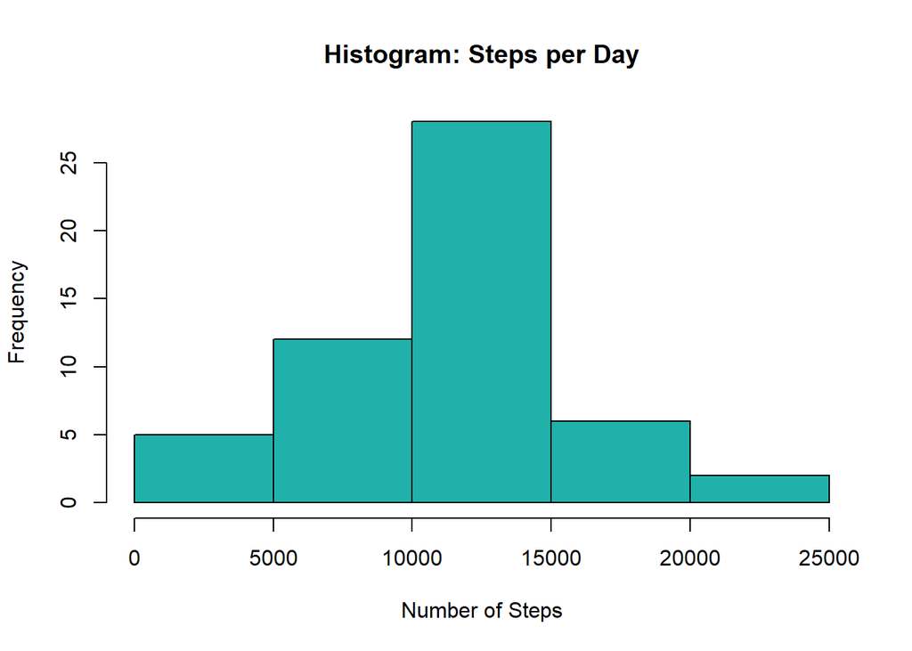

```r
totalDaily <- tapply(activity$steps, activity$date, sum)

hist(totalDaily, xlab = "Number of Steps", main = "Histogram: Steps per Day",col="lightseagreen")
```

Find mean and median for steps per day

```r
meanDaily <- mean(totalDaily,na.rm=TRUE)
medianDaily <- median(totalDaily,na.rm=TRUE)

cat("Mean is",meanDaily," and median is", medianDaily)
```

```
## Mean is 10766.19  and median is 10765
```

### Timeseries of mean steps daily and interval with max steps

Create a dataset that contains the mean number of steps per interval and plot in a line graph using ggplot

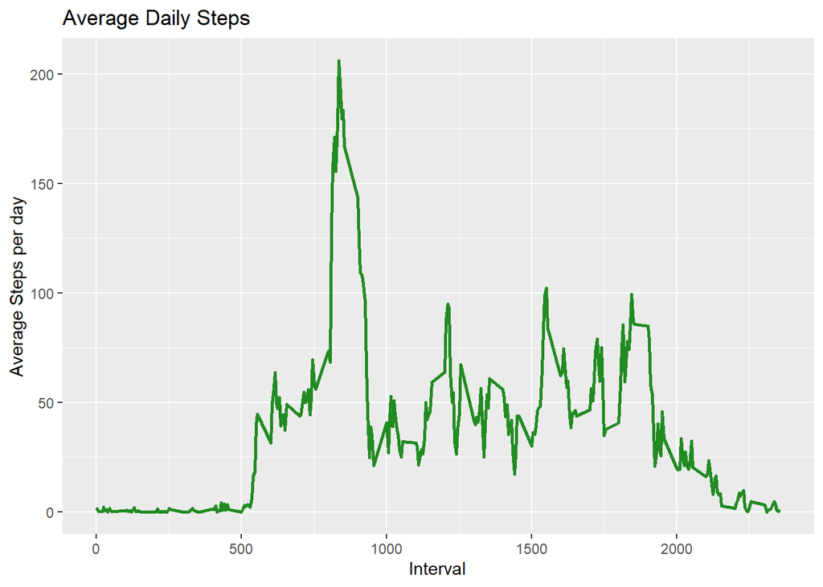

```r
intervalMean <- activity[, c(lapply(.SD, mean, na.rm = TRUE)),
                         .SDcols = c("steps"),
                         by = .(interval)]

library(ggplot2)
ggplot(intervalMean, aes(x = interval , y = steps)) +
  geom_line(color="forestgreen", size=1) +
  labs(title = "Average Daily Steps",
       x = "Interval",
       y = "Average Steps per day")
```

Find 5-minute interval with the maximum number of steps

Find the 5 minute interval with max steps

```r
intervalMean[steps == max(steps), .(max_interval = interval)]
```

```
##    max_interval
## 1:          835
```

### Imputing missing values

First, we check how many NAs we have in the dataset

```r
nrow(activity[is.na(activity$steps),])
```

```
## [1] 2304
```

```r
totalInterval <- tapply(activity$steps, activity$interval, sum)
```

Then, we want to split the bigger dataset per interval.

```r
activity.split <- split(activity, activity$interval)
```

```r
for(i in 1:length(activity.split)){
  activity.split[[i]]$steps[is.na(activity.split[[i]]$steps)] <- totalInterval[i]
}

activity.imputed <- do.call("rbind", activity.split)
```

Taking both data with NA and data with no NAs to create a histogram

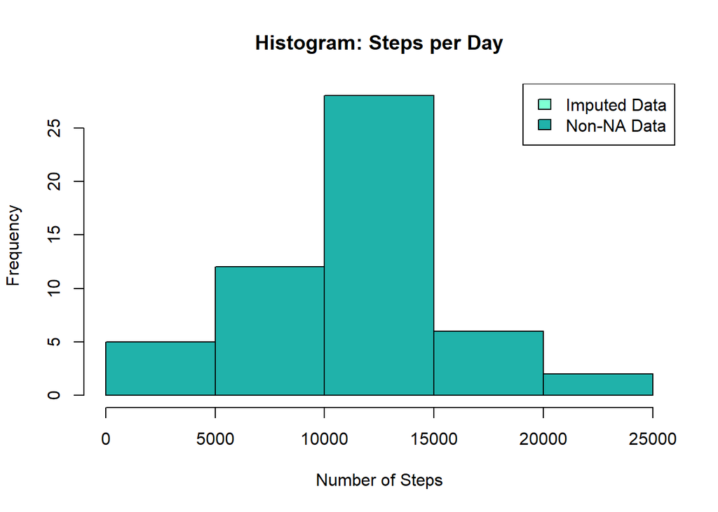

```r
totalDaily.imputed <- tapply(activity$steps, activity$date, sum)

hist(totalDaily.imputed, xlab = "Number of Steps", main = "Histogram: Steps per Day",col="aquamarine")
hist(totalDaily, xlab = "Number of Steps", main = "Histogram: Steps per Day",col="lightseagreen",add=T)
legend("topright", c("Imputed Data", "Non-NA Data"), fill=c("aquamarine", "lightseagreen") )
```

```r
meanDaily.imputed <- mean(totalDaily.imputed,na.rm=TRUE)
medianDaily.imputed <- median(totalDaily.imputed,na.rm=TRUE)

cat("Mean for non-NA data:",meanDaily,"and mean for imputed data", meanDaily.imputed)
```

```
## Mean for non-NA data: 10766.19 and mean for imputed data 10766.19
```

```r
cat("Median for non-NA data:",medianDaily,"and median for imputed data", medianDaily.imputed)
```

```
## Median for non-NA data: 10765 and median for imputed data 10765
```

## Are there differences in the activity pattern between weekdays and weekends?

First, we create a new dataset which is original activity dataset with an additional column that tags an observation as either weekend or weekday.

```r
activity.imputed$day <- ifelse(weekdays(as.Date(activity.imputed$date)) == "Saturday" | weekdays(as.Date(activity.imputed$date)) == "Sunday", "weekend", "weekday")
```

Take the mean observations for weekdays and weekends respectively

```r
library(plyr); library(dplyr)
totalDay <- ddply(activity.imputed, .(interval, day), summarize, meanDay = mean(steps, na.rm=TRUE))
```

Create a two panel plot

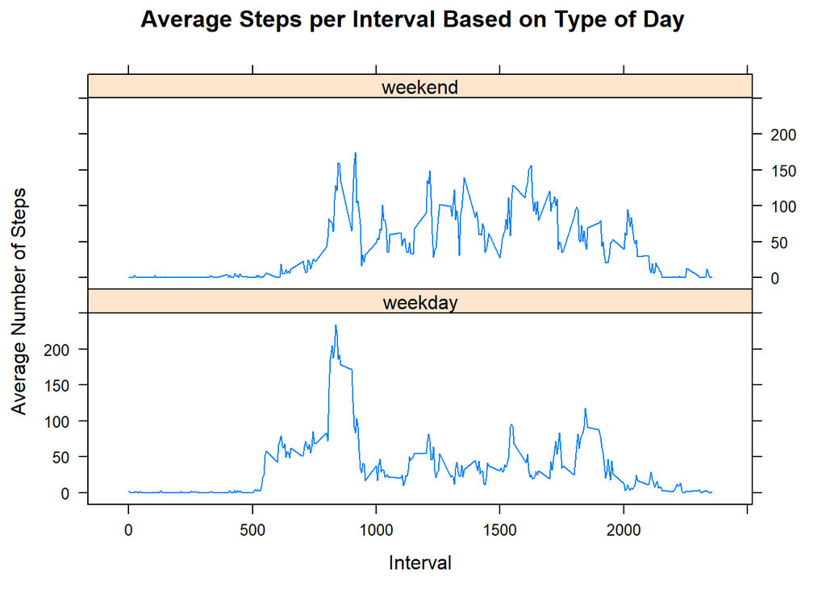

```r
library(lattice)
xyplot(meanDay~interval|day, data=totalDay, type="l",  layout = c(1,2),
       main="Average Steps per Interval Based on Type of Day",
       ylab="Average Number of Steps", xlab="Interval")
```